# Why Global Technology Is Splitting into Blocs

Stephen Weymouth

Dean’s Professor

2026-11-30

# In January 2025 the United States capped the AI chips the UAE could buy. Four months later it agreed to help build a 5-gigawatt AI campus in Abu Dhabi.

## Your IB Voice

Chips for alignment

In 2025 the UAE agreed to follow U.S. security rules and invest in U.S. data centers in exchange for Nvidia’s most advanced chips. Using the reading, explain why governments bargain over one company’s chips.

**10 minutes** · Individual · Notes permitted

## Competing explanations

Why is global technology splitting into blocs?

Rivals such as the United States and China do not share strategic technology.

Voters turned against globalization, and governments followed.

The United States, China, and Europe disagree about data, speech, and privacy.

A few firms control what AI requires, and governments are trying to control them.

Which explains a U.S. cap on chip sales to a partner such as the UAE?

# Who controls what AI requires?

## The AI stack is a value chain

[figure not shown]

Weymouth, “Digital Disintegration,” *International Organization*, 2025, and “Who Controls AI?,” public lecture, 2026.

Each step is an input to the next. I call chips, compute, and models the *critical AI inputs*.

## Nvidia sells nine in ten data center GPUs

[figure not shown]

ASML; [IoT Analytics](https://iot-analytics.com/leading-generative-ai-companies/), 2025; [TrendForce](https://www.trendforce.com/presscenter/news/20260909-13225.html), 2026; Synergy Research Group, 2026.

Nvidia designs the chips (GPUs) that train most AI models, and TSMC makes them.

ASML alone makes the machines that print the most advanced chips.

A government that wants advanced AI must deal with these firms.

## Nvidia’s software sets a private rule for AI

[figure not shown]

Geekerwan, Nvidia H100, 2023 · Wikimedia Commons, CC BY 3.0

Most AI software runs on CUDA, Nvidia’s programming interface, which works only on Nvidia chips.

Nvidia’s license bars translation layers that would run CUDA software on rivals’ chips.

I call these “privately enforced rules with global reach.”

## Governing: digital warlords

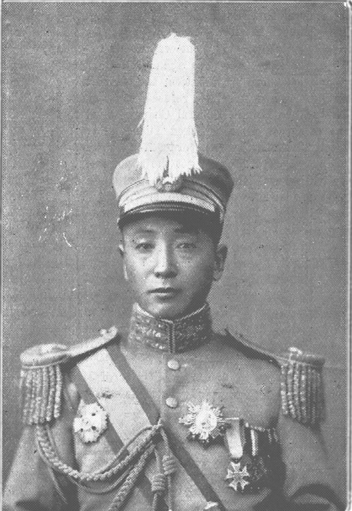

[Zhang Zuolin](https://commons.wikimedia.org/wiki/File:Zhang_Zuolin.jpg), from *Who’s Who in China*, 1925 · Wikimedia Commons, public domain

A few firms decide who may use advanced AI, and on what terms.

Like warlords, they hold power where institutional authority is weak.

*Infrastructural AI power* is a private firm’s capacity to govern access to AI by controlling its technical foundations.

## This power creates three problems for states

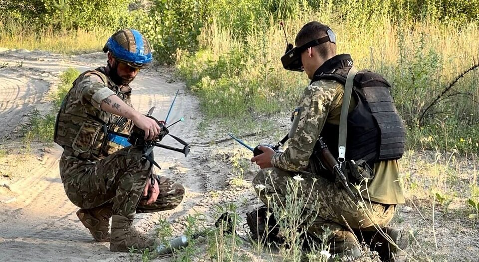

ArmyInform, [Ukrainian soldiers with a strike drone](https://commons.wikimedia.org/wiki/File:UA_FPV_strike_drones_01.jpg), 2023 · Wikimedia Commons, CC BY 4.0

**Political:** platforms shape what citizens see.

**Security:** commercial AI can guide drones and cyberattacks.

**Economic:** digital firms shift profits to low-tax jurisdictions, as Apple did.

Firms can innovate faster than states can restrain them.

# Why can’t the trade rules handle it?

# In November 2023, 28 countries, including the United States and China, signed one AI declaration at Bletchley Park. It warned of “serious, even catastrophic, harm.”

# In Paris in February 2025, about 60 countries signed. The United States and the United Kingdom declined.

# A humanoid robot runs on an AI model and cleans an office. Under world trade rules, is it a good or a service?

## Compensation

In Module 7, governments could compensate workers who lost from trade. Why doesn’t compensation solve this problem?

Who loses here: workers, or the state itself?

## The rules fail in two ways

[figure not shown]

Weymouth, “Digital Disintegration,” *International Organization*, 2025.

The trade regime was built to discipline states, so governments now act on their own to control firms.

# How are states taking control?

## U.S. controls narrowed China’s access to chips

[figure not shown]

U.S. Bureau of Industry and Security, 2022 to 2026; Weymouth, “Digital Disintegration,” 2025.

The United States needed Japan and the Netherlands, because Tokyo Electron and ASML make machines that chipmakers cannot replace.

*AI mercantilism* uses trade policy to secure national control of AI and exclude rivals.

## China’s share of Nvidia’s sales fell by half

[figure not shown]

Nvidia, [Form 10-K](https://www.sec.gov/Archives/edgar/data/1045810/000104581026000021/nvda-20260125.htm), fiscal 2026: customers headquartered in China, including Hong Kong.

In April 2025 the United States required a license for the chip Nvidia designed for China.

By February 2026 Nvidia said it was “effectively foreclosed” from China’s data center market.

Two governments shaped where Nvidia could sell.

# In 2024 Congress banned TikTok unless its Chinese owner sold it. Since January 2026 Oracle, Silver Lake, and Abu Dhabi’s MGX have led the venture that runs it in the United States.

## One U.S. rule sorted the world into three tiers

[figure not shown]

U.S. Bureau of Industry and Security, Framework for Artificial Intelligence Diffusion, January 2025.

In May 2025, two days before the caps were to bind, the United States said it would drop the rule, and it then bargained country by country.

## The UAE traded capital and energy for chips

[figure not shown]

U.S. Department of Commerce and White House, May 15, 2025; Weymouth, “Digital Disintegration,” 2025.

The Emirati firm G42 builds the campus, and U.S. cloud providers operate it.

Saudi Arabia struck a parallel deal for its new AI firm, Humain.

In an *alignment strategy*, a smaller state offers inputs in exchange for a place in a bloc.

## Chinese cloud firms run 97 zones in third countries

[figure not shown]

Lehdonvirta, Wu, and Hawkins, [*Review of International Political Economy*](https://doi.org/10.1080/09692290.2025.2489077), 2025.

At home, data laws and antitrust cases keep China’s technology firms aligned with the state.

Abroad, the Digital Silk Road bundles cloud, cables, and surveillance, as in Huawei’s Safe City in Islamabad.

These exports deepen partners’ dependence on Chinese firms.

# Chinese developers produced 41 percent of the open AI models downloaded from Hugging Face in the year to spring 2026, more than U.S. developers.

## The EU trades market access for compliance

[figure not shown]

Daniel from Glasgow, Berlaymont building, Brussels, 2019 · Wikimedia Commons, CC BY 2.0

The AI Act binds any company that offers AI to users in the EU, wherever it is based.

France and Germany are building “sovereign” AI with Nvidia chips, OpenAI models, and UAE capital.

*Regulatory sovereignty* turns the EU’s market size into authority over firms it does not host.

## The AI Act regulates a firm by how it uses AI

[figure not shown]

European Commission, [AI Act](https://digital-strategy.ec.europa.eu/en/policies/regulatory-framework-ai), Regulation (EU) 2024/1689, as amended in 2026.

A firm that uses AI to hire or score credit will have to keep a person in charge, keep records, and tell those affected.

A firm with a customer chatbot must already say that it is a machine.

The EU moved the high-risk duties from August 2026 to December 2027.

# Pax Silica, a U.S.-led declaration on AI supply chains, has 26 signatories. The World AI Cooperation Organization, founded in Shanghai in 2026, has 29 founding members.

## Controlling: strategic digital sovereignty

[figure not shown]

Weymouth, “Digital Disintegration,” *International Organization*, 2025.

States act alone where they can.

They ally with firms and other governments where they cannot.

*Strategic digital sovereignty* is state authority over core digital infrastructure, exercised alone or through selective alliances.

## Joining: the techno-bloc

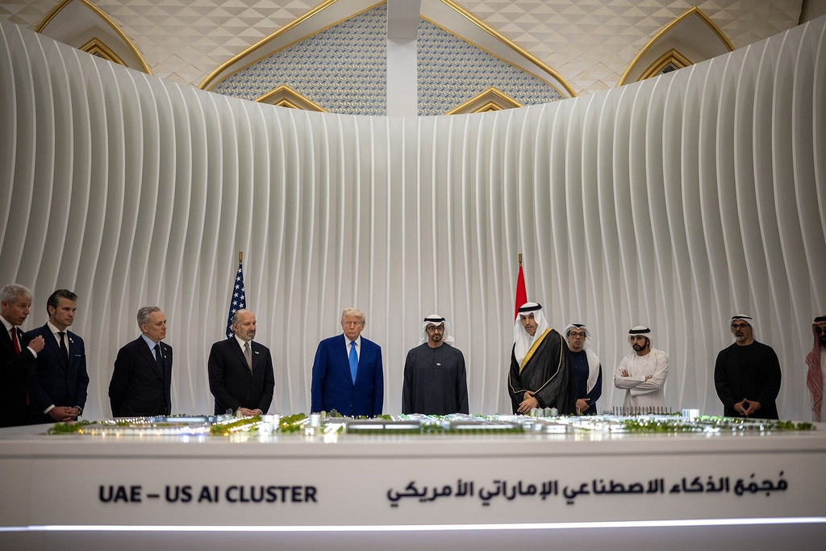

Daniel Torok, The White House, [Abu Dhabi, May 15, 2025](https://commons.wikimedia.org/wiki/File:Donald_Trump_state_visit_to_the_United_Arab_Emirates,_2025-05-15_P20250515DT-3149.jpg) · Wikimedia Commons, public domain

States trade inputs and lower barriers for markets and advanced technology.

A state may join several blocs at once.

A *techno-bloc* is a coalition of governments and dominant firms that controls key AI inputs and excludes others.

## A firm’s terms collided with a state’s demands

[figure not shown]

Anthropic PBC v. Department of War (N.D. Cal. 2026); State of AI Report 2026.

Anthropic’s terms bar using its models for mass surveillance of Americans or for autonomous weapons without human oversight.

Such firms are “independent centers of power that governments cannot fully control.”

# The Wall Street Journal reported in November 2026 that the Commerce Department plans to name more than two dozen AI firms “national champions,” including Nvidia, Microsoft, Amazon, OpenAI, and Anthropic.

## Firms and openness

Large multinationals once lobbied for open markets. Why do Nvidia, Oracle, and OpenAI now side with governments that restrict trade?

What does a bloc give a firm that an open market does not?

## The United States offers you a chip deal

[figure not shown]

**Sign, counter, or walk away.** Name your leverage.

**10 minutes** · Groups of four · 6 to decide, 4 to report

[figure not shown]

**Malaysia:** a data center boom with American and Chinese tenants.

[figure not shown]

**South Korea:** two firms that make most of AI’s memory chips.

[figure not shown]

**India:** 1.4 billion people and a tax on foreign online ads.

[figure not shown]

**United Kingdom:** a tax on big platforms and a new online safety law.

## What the four governments did

What did the four governments do?

[figure not shown]

**Malaysia** signed, and promised to match U.S. export controls. The deal was never ratified.

[figure not shown]

**South Korea** got 260,000 Nvidia chips and promised not to discriminate against U.S. platforms.

[figure not shown]

**India** dropped its ad tax and joined Pax Silica.

[figure not shown]

**The United Kingdom** kept its tax, and the United States suspended their technology deal.

Which government had the most leverage, and why?

## Techno-blocs replace rules with deals

[figure not shown]

Weymouth, “Digital Disintegration,” *International Organization*, 2025; schematic.

I call the result *illiberal alignment*: opaque, transactional, and exclusive.

## Closing discussion

Constraining AI firms would take international rules on data, competition, and digital taxes. Which governments would agree to them?

On Wednesday, Dani Rodrik asks whether democracy, national sovereignty, and deep globalization can coexist.

## Takeaways

Why is global technology splitting into blocs?

A few private firms control the chips, compute, and models that AI requires.

Trade and tax rules were built for states, so they constrain neither the firms nor the states’ responses.

States respond with controls of their own and with techno-blocs that bind partner governments and firms.

The blocs replace multilateral rules with deals that are opaque, transactional, and exclusive.